# Housing Density, Income, and Uninsured Rates in Chicago’s South Side: A Tract-Level Analysis

Author

Grace Yao, Jiamin Zhang, Yuxin Zheng

Published

March 4, 2026

**Group Members:** Grace Yao, Jiamin Zhang, Yuxin Zheng

**Section:** Tuesday 11:00 am – 12:20 pm, Section 4

**GitHub:** [GraceYYYY07,Yuxin217-u,jasmine420222]

# Motivation and Research Question

Chicago’s South Side has long been associated with persistent economic inequality and disparities in access to healthcare. Neighborhood characteristics such as income levels, housing density, and residential concentration may shape how easily residents can access health insurance and healthcare services.

Our project asks the following descriptive research question:

How are housing density and neighborhood income associated with uninsured rates at the Census Tract level in Chicago’s South Side?

The goal of this project is not to identify causal relationships, but rather to examine spatial patterns. If areas with high residential density and low income also exhibit high uninsured rates, those neighborhoods may represent priority locations for policy interventions such as targeted enrollment campaigns or community health clinics.

# Data and Approach

We combine two datasets for this analysis.

The first dataset is a residential address dataset containing approximately 46,000 building addresses with latitude and longitude coordinates as well as the number of housing units per building. These addresses are used to construct a proxy for housing density at the census tract level.

The second dataset is the Illinois Census tract shapefile, which includes tract boundaries as well as socioeconomic variables such as median household income and uninsured rates derived from the American Community Survey.

In an earlier version of the project we used the dataset `obama_addresses_mappable_t.csv`, which only covered the geographic area surrounding the Obama Presidential Library. Because that dataset represented only a small portion of Chicago’s South Side, it produced many tracts with zero density values and did not accurately represent residential patterns across the region. To address this limitation, we replaced that dataset with a larger address dataset that covers the broader South Side.

Data processing is implemented in `preprocessing.py`. Address coordinates are converted into geographic points and spatially joined with census tract polygons. Addresses are then aggregated by tract to calculate address density, measured as addresses per square kilometer. The resulting density values are merged with census tract income and uninsured rate data to produce the final tract-level dataset used for analysis.

# Static Visualizations

### Figure 1: Median Income by Census Tract

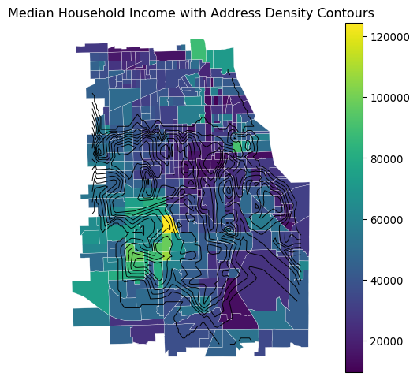

Figure 1 shows the spatial distribution of median household income across census tracts in Chicago’s South Side. Lower-income tracts cluster in several central areas of the South Side, illustrating the geographic concentration of economic disadvantage.

### Figure 2: Address Density vs Uninsured Rate

[interactive chart not shown]

Figure 2 examines the relationship between housing density and uninsured rates. Each point represents a census tract, with color indicating the tract’s income quartile.

The figure shows that uninsured rates vary strongly across income groups. Lower-income tracts consistently exhibit higher uninsured rates, while higher-income tracts tend to have lower uninsured rates. In contrast, housing density alone does not appear to strongly predict uninsured rates, suggesting that income differences play a larger role in explaining insurance disparities.

# Streamlit App

To complement the static visualizations, we built an interactive Streamlit dashboard that allows users to explore these relationships across Chicago’s South Side.

The dashboard includes an interactive map showing census tract boundaries along with tract-level indicators such as median income, address density, and uninsured rates. Users can hover over tracts to view detailed values for each variable.

The dashboard also includes scatter plots comparing income and uninsured rates as well as density and uninsured rates. In addition, users can adjust slider thresholds that define “priority tracts” based on combinations of low income, high uninsured rates, and high residential density. Tracts meeting these criteria are highlighted on the map.

This interactive tool allows policymakers to explore how different policy priorities might change the set of neighborhoods identified as high-priority areas for outreach or intervention.

# Weaknesses & Difficulties

Several limitations should be considered when interpreting these results.

First, address counts are only a proxy for residential density and may not perfectly represent the number of households in each tract.

Second, the analysis is descriptive rather than causal. Many other factors—such as age distribution, employment patterns, or demographic composition—may influence uninsured rates but are not included in this analysis.

Third, American Community Survey estimates contain sampling error, particularly at the census tract level.

Despite these limitations, the analysis provides a useful overview of how housing density, income, and uninsured rates are spatially distributed across Chicago’s South Side.